# Homework #6

```r
# get maximum likelihood parameters for normal
normPars <- fitdistr(myVar,"normal")
print(normPars)
```

```
##       mean          sd
##   10.8289333    4.5714441
##  ( 0.1442735) ( 0.1020168)
```

```r
str(normPars)
```

```
## List of 5
##  $ estimate: Named num [1:2] 10.83 4.57
##   ..- attr(*, "names")= chr [1:2] "mean" "sd"
##  $ sd      : Named num [1:2] 0.144 0.102
##   ..- attr(*, "names")= chr [1:2] "mean" "sd"
##  $ vcov    : num [1:2, 1:2] 0.0208 0 0 0.0104
##   ..- attr(*, "dimnames")=List of 2
##   .. ..$ : chr [1:2] "mean" "sd"
##   .. ..$ : chr [1:2] "mean" "sd"
##  $ n       : int 1004
##  $ loglik  : num -2951
##  - attr(*, "class")= chr "fitdistr"
```

```r
normPars$estimate["mean"] # get named attribute
```

```
##     mean
## 10.82893
```

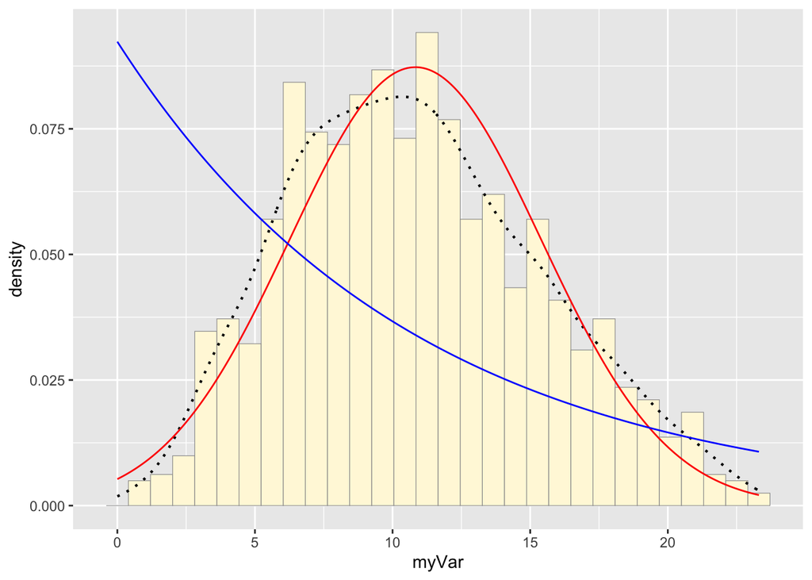

```r
# plot normal probability density using mean and sd
meanML <- normPars$estimate["mean"]
sdML <- normPars$estimate["sd"]

xval <- seq(0,max(myVar),len=length(myVar))

stat <- stat_function(aes(x = xval, y = ..y..), fun = dnorm, colour="red", n = length(myVar), args = list(mean = meanML, sd = sdML))
p1 + stat
# plot exponential probability density
expoPars <- fitdistr(myVar,"exponential")
rateML <- expoPars$estimate["rate"]

stat2 <- stat_function(aes(x = xval, y = ..y..), fun = dexp, colour="blue", n = length(myVar), args = list(rate=rateML))
p1 + stat + stat2
```

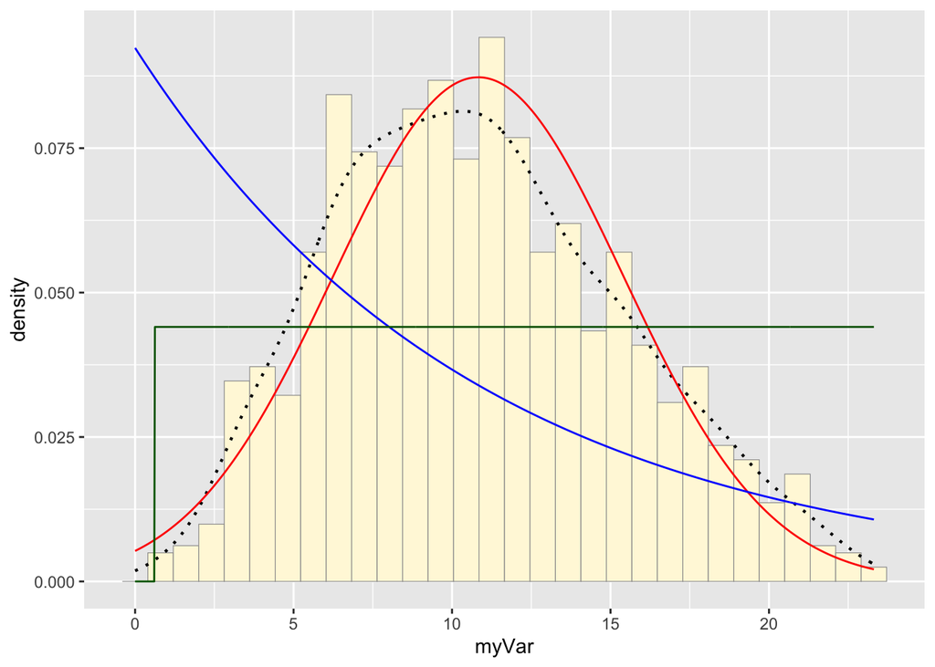

```r
# plot uniform probability density
stat3 <- stat_function(aes(x = xval, y = ..y..), fun = dunif, colour="darkgreen", n = length(myVar), args = list(min=min(myVar), max=max(myVar)))
p1 + stat + stat2 + stat3
```

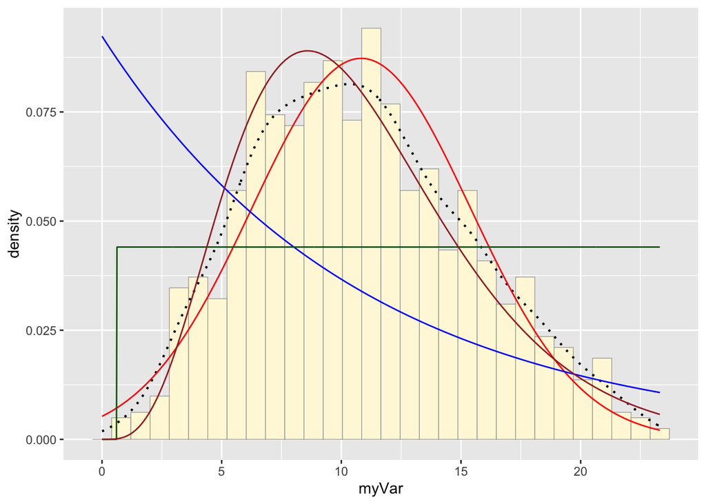

```r
# plot gamma probability density
gammaPars <- fitdistr(myVar,"gamma")
shapeML <- gammaPars$estimate["shape"]
rateML <- gammaPars$estimate["rate"]

stat4 <- stat_function(aes(x = xval, y = ..y..), fun = dgamma, colour="brown", n = length(myVar), args = list(shape=shapeML, rate=rateML))
p1 + stat + stat2 + stat3 + stat4
```

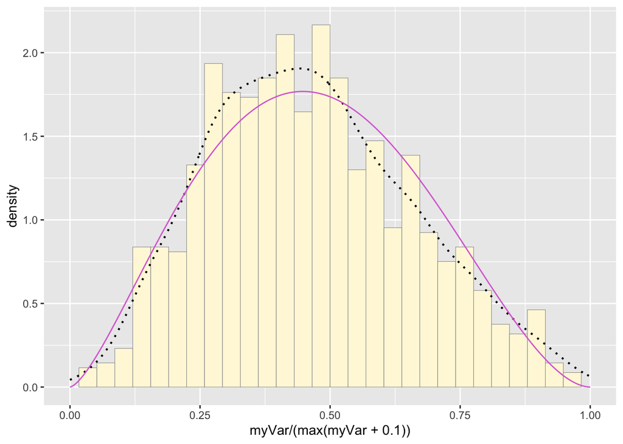

```r
# plot beta probability density
pSpecial <- ggplot(data=z, aes(x=myVar/(max(myVar + 0.1)), y=..density..)) +
  geom_histogram(color="grey60",fill="cornsilk",size=0.2) +
  xlim(c(0,1)) +
  geom_density(size=0.75,linetype="dotted")

betaPars <- fitdistr(x=myVar/max(myVar + 0.1),start=list(shape1=1,shape2=2),"beta")
shape1ML <- betaPars$estimate["shape1"]
shape2ML <- betaPars$estimate["shape2"]

statSpecial <- stat_function(aes(x = xval, y = ..y..), fun = dbeta, colour="orchid", n = length(myVar), args = list(shape1=shape1ML,shape2=shape2ML))
pSpecial + statSpecial
```

- *Comment out the “fake data” used for simulation*
  - Not commenting out so that it is easier for me to use this coursework as a resource in the furture. That said, happy to coment out if you need me to for any reason :)
- **Question #3**
- *Find best-fitting distribution. Take a look at the second-to-last graph which shows the histogram of your data and 4 probability density curves (normal, uniform, exponential, gamma) that are fit to the data. Find the best-fitting distribution for your data. For most data sets, the gamma will probably fit best, but if you data set is small, it may be very hard to see much of a difference between the curves. The beta distribution in the final graph is somewhat special. It often fits the data pretty well, but that is because we have assumed the largest data point is the true upper bound, and everything is scaled to that. The fit of the uniform distribution also fixes the upper bound. The other curves (normal, exponential, and gamma) are more realistic because they do not have an upper bound.*

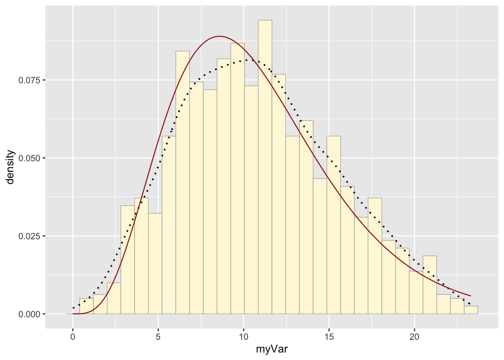

```r
# There are two distributions that fit the data set
# As predicted, the gamma fits the data set
gammaPars <- fitdistr(myVar,"gamma")
shapeML <- gammaPars$estimate["shape"]
rateML <- gammaPars$estimate["rate"]

stat4 <- stat_function(aes(x = xval, y = ..y..), fun = dgamma, colour="brown", n = length(myVar), args = list(shape=shapeML, rate=rateML))
p1 + stat4
```

```r
stat4
```

[output not shown]

```r
# But the normal also is a pretty good fit
meanML <- normPars$estimate["mean"]
sdML <- normPars$estimate["sd"]

xval <- seq(0,max(myVar),len=length(myVar))

stat <- stat_function(aes(x = xval, y = ..y..), fun = dnorm, colour="red", n = length(myVar), args = list(mean = meanML, sd = sdML))
p1 + stat
```

[output not shown]

- **Question #4**
- *Using the best-fitting distribution, go back to the code and get the maximum likelihood parameters*

```r
# Both the gamma and the normal distributions fit the data pretty well. I am going to explore both.
# I'll get the ML parameters for both the normal and the gamma distributions

# The parameters for the normal distribution are mean and sd
# I can get them all at once, or one at a time

# get maximum likelihood parameters for normal
normPars <- fitdistr(myVar,"normal")
print(normPars)
```

```
##       mean          sd
##   10.8289333    4.5714441
##  ( 0.1442735) ( 0.1020168)
```

```r
# mean          sd
# 10.8289333    4.5714441
# ( 0.1442735) ( 0.1020168)

# call the structure of the normal distribution
str(normPars)
```

```
## List of 5
##  $ estimate: Named num [1:2] 10.83 4.57
##   ..- attr(*, "names")= chr [1:2] "mean" "sd"
##  $ sd      : Named num [1:2] 0.144 0.102
##   ..- attr(*, "names")= chr [1:2] "mean" "sd"
##  $ vcov    : num [1:2, 1:2] 0.0208 0 0 0.0104
##   ..- attr(*, "dimnames")=List of 2
##   .. ..$ : chr [1:2] "mean" "sd"
##   .. ..$ : chr [1:2] "mean" "sd"
##  $ n       : int 1004
##  $ loglik  : num -2951
##  - attr(*, "class")= chr "fitdistr"
```

```r
# normPars$estimate["mean"] # get named attribute
# List of 5
# $ estimate: Named num [1:2] 10.83 4.57
# ..- attr(*, "names")= chr [1:2] "mean" "sd"
# $ sd      : Named num [1:2] 0.144 0.102
# ..- attr(*, "names")= chr [1:2] "mean" "sd"
# $ vcov    : num [1:2, 1:2] 0.0208 0 0 0.0104
# ..- attr(*, "dimnames")=List of 2
# .. ..$ : chr [1:2] "mean" "sd"
# .. ..$ : chr [1:2] "mean" "sd"
# $ n       : int 1004
# $ loglik  : num -2951
# - attr(*, "class")= chr "fitdistr"

# plot normal probability density using mean and sd
meanML <- normPars$estimate["mean"]
print (meanML)
```

```
##     mean
## 10.82893
```

```r
# mean = 10.82893
sdML <- normPars$estimate["sd"]
print (sdML)
```

```
##       sd
## 4.571444
```

```r
# sd = 4.571444

# The parameters for the gamma distribution are shape and rate
# I can get them all at once or one at a time

gammaPars <- fitdistr(myVar,"gamma")
# This call returns the same result as getting ML parameters separately
print(gammaPars)
```

```
##      shape         rate
##   4.83401978   0.44639828
##  (0.20872994) (0.02031225)
```

```r
# shape         rate
# 4.83401978   0.44639828
# (0.20872994) (0.02031225)

# Getting Warning messages, I think this is ok
# 1: In densfun(x, parm[1], parm[2], ...) : NaNs produced
# 2: In densfun(x, parm[1], parm[2], ...) : NaNs produced
# 3: In densfun(x, parm[1], parm[2], ...) : NaNs produced
# 4: In densfun(x, parm[1], parm[2], ...) : NaNs produced

# Extract each of the estimated parameters
shapeML <- gammaPars$estimate["shape"]
print(shapeML)
```

```
##   shape
## 4.83402
```

```r
rateML -> gammaPars$estimate["rate"]
print(rateML)
```

```
##      rate
## 0.4463983
```

```r
str(gammaPars)
```

```
## List of 5
##  $ estimate: Named num [1:2] 4.834 0.446
##   ..- attr(*, "names")= chr [1:2] "shape" "rate"
##  $ sd      : Named num [1:2] 0.2087 0.0203
##   ..- attr(*, "names")= chr [1:2] "shape" "rate"
##  $ vcov    : num [1:2, 1:2] 0.043568 0.004023 0.004023 0.000413
##   ..- attr(*, "dimnames")=List of 2
##   .. ..$ : chr [1:2] "shape" "rate"
##   .. ..$ : chr [1:2] "shape" "rate"
##  $ loglik  : num -2952
##  $ n       : int 1004
##  - attr(*, "class")= chr "fitdistr"
```

```r
# gammaPars is  a list of 5 elements
# List of 5
# $ estimate: Named num [1:2] 4.834 0.446
# ..- attr(*, "names")= chr [1:2] "shape" "rate"
# $ sd      : Named num [1:2] 0.2087 0.0203
# ..- attr(*, "names")= chr [1:2] "shape" "rate"
# $ vcov    : num [1:2, 1:2] 0.043568 0.004023 0.004023 0.000413
# ..- attr(*, "dimnames")=List of 2
# .. ..$ : chr [1:2] "shape" "rate"
# .. ..$ : chr [1:2] "shape" "rate"
# $ loglik  : num -2952
# $ n       : int 1004
# - attr(*, "class")= chr "fitdistr"
```

- *Use maximum likelihood parameters from my data set to simulate a new data set, with the same length as your original vector, and plot that in a histogram and add the probability density curve*
- Note that I adjusted the number of observations to 1000 (rather than 1004) in order to check that I was modeling the simulated dataset
- I am going to use the parameters from my dataset in the code that we used to generate the original practice data set

```r
# First I am going to take a look at my data set and then also my variable just for kicks
head(z)
```

```
##     Plant.ID Length
## 1 1_1_0nM_WT   3.57
## 2 1_1_0nM_WT   8.17
## 3 1_1_0nM_WT  11.35
## 4 1_1_0nM_WT  14.27
## 5 1_1_0nM_WT  16.14
## 6 1_2_0nM_WT   6.22
```

```r
#[1]  3.57  8.17 11.35 14.27 16.14  6.22
head(myVar)
```

```
## [1]  3.57  8.17 11.35 14.27 16.14  6.22
```

```r
# [1]  3.57  8.17 11.35 14.27 16.14  6.22

str(myVar)
```

```
##  num [1:1004] 3.57 8.17 11.35 14.27 16.14 ...
```

```r
#  num [1:1004] 3.57 8.17 11.35 14.27 16.14 ...
# This means that I have 1004 measurements

# use `rnorm` to simulate a new dataset with the maximum likelihood parameters of my dataset to test this as a model for the distribution of the data

# plot histogram of data to visualize
# p1 <- ggplot(data=z, aes(x=myVar, y=..density..)) +
#   geom_histogram(color="grey60",fill="cornsilk",size=0.2)

# First simulate the dataset by generating random data using the ML parameters
# I am not sure whether it make a difference if you create a single call as commented out
# below or break it up into two like we did in class.
# I am going to break it up like we did in class

#newz <- data.frame(x = rnorm(n = 1000, mean = 10.8289333))

z <- rnorm(n=1000, mean=10.8289333, sd=4.571444)
z <- data.frame(1:1000,z)
names(z) <- list("ID","newVar")
z <- z[z$newVar>0,]
str(z)
```

```
## 'data.frame':    988 obs. of  2 variables:
##  $ ID    : int  1 2 3 4 5 6 7 8 9 10 ...
##  $ newVar: num  2.07 13.49 7.13 7.5 7.62 ...
```

```r
summary(z$newVar)
```

```
##     Min.  1st Qu.   Median     Mean  3rd Qu.     Max.
##  0.01586  7.64087 10.87827 10.92643 14.06469 23.82166
```

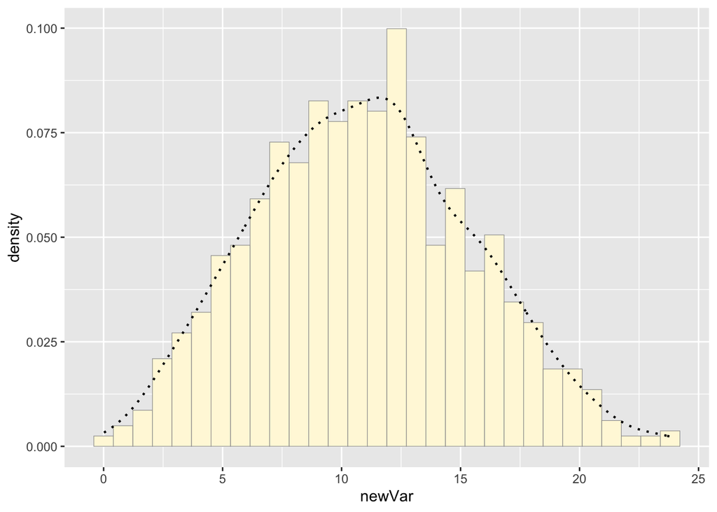

```r
# Create the histogram as a ggplot object
p1 <- ggplot(z, aes(x = newVar, y=..density..)) +
              geom_histogram(color = "grey60", fill = "cornsilk", size = 0.2) +
              geom_density(linetype = "dotted", size = 0.75)

# Display the plot
print(p1)
```

```r
#str(newVar)
#print (newVar)

# Get maximum likelihood parameters for normal by calling fitdistr
# Fit a normal distribution to the data and grab the maximum likelihood estimators
# of the two parameters of the normal, the mean and the variance
# The simulated dataset should be the same as with the original because it was
# generated with the ML parameters...right?
normPars <- fitdistr(z$newVar,"normal")
print(normPars)
```

```
##       mean          sd
##   10.9264303    4.5291137
##  ( 0.1440903) ( 0.1018872)
```

```r
str(normPars)
```

```
## List of 5
##  $ estimate: Named num [1:2] 10.93 4.53
##   ..- attr(*, "names")= chr [1:2] "mean" "sd"
##  $ sd      : Named num [1:2] 0.144 0.102
##   ..- attr(*, "names")= chr [1:2] "mean" "sd"
##  $ vcov    : num [1:2, 1:2] 0.0208 0 0 0.0104
##   ..- attr(*, "dimnames")=List of 2
##   .. ..$ : chr [1:2] "mean" "sd"
##   .. ..$ : chr [1:2] "mean" "sd"
##  $ n       : int 988
##  $ loglik  : num -2894
##  - attr(*, "class")= chr "fitdistr"
```

```r
#Plot normal probability density
meanML <- normPars$estimate["mean"]
sdML <- normPars$estimate["sd"]

xval <- seq(0,max(z$newVar),len=length(z$newVar))
# xval <- seq(min(newVar), max(newVar), length.out = length(newVar))

# print (xval)
str(xval)
```

```
##  num [1:988] 0 0.0241 0.0483 0.0724 0.0965 ...
```

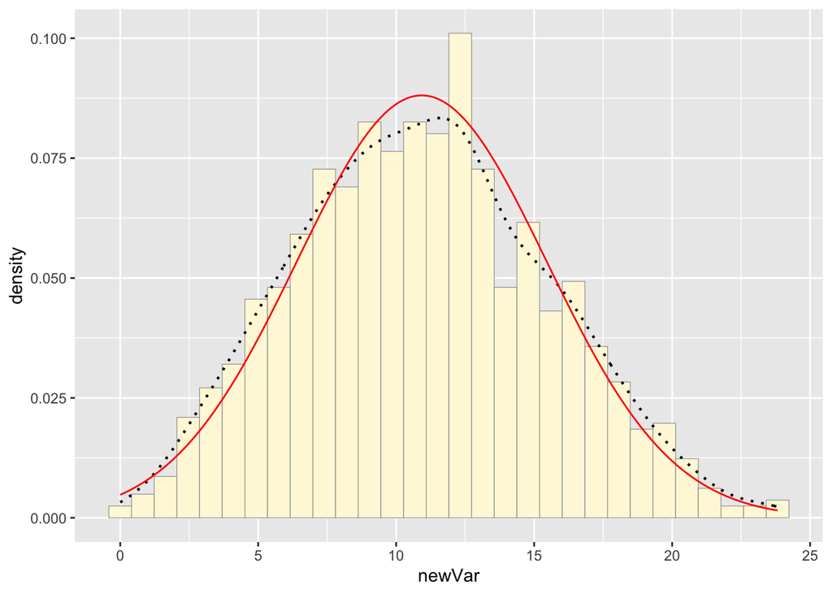

```r
# pass the parameters (meanML and sdML) to stat_function
# Call the dnorm function inside ggplot’s stat_function to generate the probability density for the normal distribution.
stat <- stat_function(aes(x = xval, y = ..y..), fun = dnorm, colour="red", n = length(z$newVar), args = list(mean = meanML, sd = sdML))
p1 + stat
```

[output not shown]

- *How do the two histogram profiles compare? Do you think the model is doing a good job of simulating realistic data that match your original measurements? Why or why not?*

  The histogram profiles are similar. The simulated data is a relatively good model with some reservations:
  - the slope of the curve from the mean is steeper in the simulation
  - the tails are more protracted/elongated in the simulation

  Additional work may be needed to identify a better fitting model depending on the application
- *If you have entered a large data frame with many columns, try running all of the code on a different variable to see how the simulation performs.*

  The dataframe entered only has two columns, so this does not apply.